# Day 01 - Exercise 01 - Intro Exercises

Victor Calderon

14 August, 2018

This are the responses/answers to the problems posed by the exercises in the `Intro.R` file.

## Exercise 1.1

> Look through the help file for `plot`, then recreate any figure above and set the subtitle to `subtitle`.

```r
help(plot)
```

Now we can recreate the figure as in `intro.R`:

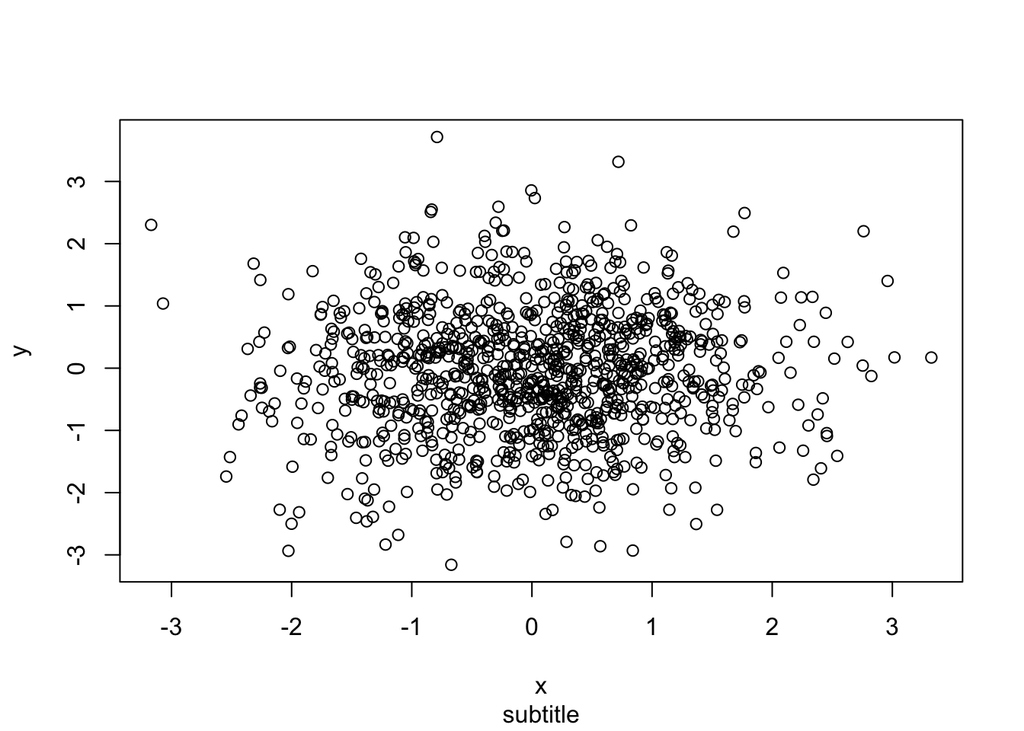

```r
x = rnorm(1000)
y = rnorm(1000)
plot(x, y, sub = 'subtitle')
```

## Exercise 1.2

> Find two different expressions to create a 3 x 3 (row x col) matrix with the values 2, 4, and 6 in the rows.

## Exercise 1.3

> What happens when you collate (`c()`) a list and a vector? List and a list?

## Exercise 1.4

> Install and load the `manipulate` package.

## Exercise 1.5

> Use the `manipulate` function to interactively vary the `phi` argument to `persp` in the above example. Use `persp(x,y,fa,theta=30,phi=phi_slider)` as the first argument (see the `manipulate` help file and examples).

## Exercise 1.6

> Generate 10 values from the normal distribution with mean 5 and sd 3 and compute their sample mean.

## Exercise 1.7

> Use the `replicate` function to repeat item 6. 1000 times.

## Exercise 1.8

> Use the `hist` function to plot a histogram of the sample means from item 7. Repeat where `N = 50` instead of `10`. Use the `add = TRUE` and `col = "red"` arguments to the ‘hist’ function to add the second histogram to the first for for comparison.